# Detecting Potentially Hazardous Asteroids

Capstone Project

Group 3: Rayna Liu, Zheyue Wang

```python
import pandas as pd
import numpy as np
from sklearn.preprocessing import LabelEncoder
from sklearn.model_selection import train_test_split
from sklearn.preprocessing import StandardScaler
from imblearn.over_sampling import SMOTE
from imblearn.under_sampling import RandomUnderSampler

# Models
from sklearn.ensemble import RandomForestClassifier
from xgboost import XGBClassifier
from sklearn.tree import DecisionTreeClassifier
from sklearn.naive_bayes import GaussianNB
from sklearn.linear_model import LogisticRegression
from sklearn.svm import SVC
from sklearn.neighbors import KNeighborsClassifier
from sklearn import metrics
from sklearn.metrics import precision_recall_fscore_support, confusion_matrix, classification_report, accuracy_score
from sklearn.model_selection import GridSearchCV

# Visualization
import seaborn as sns
import matplotlib.pyplot as plt
from sklearn import tree
from xgboost import plot_tree

# Other
import warnings
warnings.filterwarnings("ignore")
from datetime import datetime
```

## TensorFlow

```python
# Allow us to use tensorflow
import tensorflow as tf
from tensorflow import keras
from keras.models import Sequential
from keras.layers import Dense, Dropout, BatchNormalization
from tensorflow.keras.optimizers import Adam, SGD
from keras.callbacks import ModelCheckpoint, EarlyStopping, ReduceLROnPlateau
```

## Load Astroid Dataset

```python
# Load the asteroid dataset
raw_data=pd.read_csv('dataset.csv.zip', compression='zip')
raw_data.head(50)
```

|  | id | spkid | full_name | pdes | name | prefix | neo | pha | H | diameter | ... | sigma_i | sigma_om | sigma_w | sigma_ma | sigma_ad | sigma_n | sigma_tp | sigma_per | class | rms |
| --- | --- | --- | --- | --- | --- | --- | --- | --- | --- | --- | --- | --- | --- | --- | --- | --- | --- | --- | --- | --- | --- |
| 0 | a0000001 | 2000001 | 1 Ceres | 1 | Ceres | NaN | N | N | 3.40 | 939.400 | ... | 4.608900e-09 | 6.168800e-08 | 6.624800e-08 | 7.820700e-09 | 1.111300e-11 | 1.196500e-12 | 3.782900e-08 | 9.415900e-09 | MBA | 0.43301 |
| 1 | a0000002 | 2000002 | 2 Pallas | 2 | Pallas | NaN | N | N | 4.20 | 545.000 | ... | 3.469400e-06 | 6.272400e-06 | 9.128200e-06 | 8.859100e-06 | 4.961300e-09 | 4.653600e-10 | 4.078700e-05 | 3.680700e-06 | MBA | 0.35936 |
| 2 | a0000003 | 2000003 | 3 Juno | 3 | Juno | NaN | N | N | 5.33 | 246.596 | ... | 3.223100e-06 | 1.664600e-05 | 1.772100e-05 | 8.110400e-06 | 4.363900e-09 | 4.413400e-10 | 3.528800e-05 | 3.107200e-06 | MBA | 0.33848 |
| 3 | a0000004 | 2000004 | 4 Vesta | 4 | Vesta | NaN | N | N | 3.00 | 525.400 | ... | 2.170600e-07 | 3.880800e-07 | 1.789300e-07 | 1.206800e-06 | 1.648600e-09 | 2.612500e-10 | 4.103700e-06 | 1.274900e-06 | MBA | 0.39980 |
| 4 | a0000005 | 2000005 | 5 Astraea | 5 | Astraea | NaN | N | N | 6.90 | 106.699 | ... | 2.740800e-06 | 2.894900e-05 | 2.984200e-05 | 8.303800e-06 | 4.729000e-09 | 5.522700e-10 | 3.474300e-05 | 3.490500e-06 | MBA | 0.52191 |
| 5 | a0000006 | 2000006 | 6 Hebe | 6 | Hebe | NaN | N | N | 5.80 | 185.180 | ... | 2.191800e-06 | 1.122100e-05 | 1.300600e-05 | 7.392200e-06 | 3.306700e-09 | 4.438800e-10 | 2.875400e-05 | 2.344500e-06 | MBA | 0.41032 |
| 6 | a0000007 | 2000007 | 7 Iris | 7 | Iris | NaN | N | N | 5.60 | 199.830 | ... | 2.582500e-06 | 2.641200e-05 | 2.707500e-05 | 7.014700e-06 | 2.469500e-09 | 3.370100e-10 | 2.662700e-05 | 1.699400e-06 | MBA | 0.38128 |
| 7 | a0000008 | 2000008 | 8 Flora | 8 | Flora | NaN | N | N | 6.50 | 147.491 | ... | 3.240300e-06 | 2.432000e-05 | 2.664600e-05 | 1.209200e-05 | 2.668100e-09 | 4.746200e-10 | 4.018700e-05 | 1.876500e-06 | MBA | 0.54186 |
| 8 | a0000009 | 2000009 | 9 Metis | 9 | Metis | NaN | N | N | 6.30 | 190.000 | ... | 2.007400e-06 | 2.417000e-05 | 2.600800e-05 | 1.036600e-05 | 3.470200e-09 | 5.192700e-10 | 3.870700e-05 | 2.614600e-06 | MBA | 0.44895 |
| 9 | a0000010 | 2000010 | 10 Hygiea | 10 | Hygiea | NaN | N | N | 5.50 | 407.120 | ... | 2.173400e-06 | 2.855200e-05 | 3.023700e-05 | 1.124600e-05 | 7.699800e-09 | 5.847400e-10 | 6.482900e-05 | 6.724400e-06 | MBA | 0.53434 |
| 10 | a0000011 | 2000011 | 11 Parthenope | 11 | Parthenope | NaN | N | N | 6.50 | 142.887 | ... | 3.418800e-06 | 2.484400e-05 | 2.779100e-05 | 1.203500e-05 | 2.649900e-09 | 3.782000e-10 | 4.687300e-05 | 2.067200e-06 | MBA | 0.46367 |
| 11 | a0000012 | 2000012 | 12 Victoria | 12 | Victoria | NaN | N | N | 7.30 | 115.087 | ... | 2.517400e-06 | 1.903300e-05 | 1.994700e-05 | 7.390200e-06 | 2.887600e-09 | 4.204100e-10 | 2.710000e-05 | 1.980400e-06 | MBA | 0.54993 |
| 12 | a0000013 | 2000013 | 13 Egeria | 13 | Egeria | NaN | N | N | 6.80 | 202.636 | ... | 3.782600e-06 | 1.276500e-05 | 2.580600e-05 | 2.219600e-05 | 3.766800e-09 | 4.817600e-10 | 9.319900e-05 | 3.052100e-06 | MBA | 0.56183 |
| 13 | a0000014 | 2000014 | 14 Irene | 14 | Irene | NaN | N | N | 6.50 | 152.000 | ... | 3.503700e-06 | 2.041400e-05 | 2.297400e-05 | 1.102800e-05 | 3.829000e-09 | 4.511900e-10 | 4.669300e-05 | 2.892900e-06 | MBA | 0.53686 |
| 14 | a0000015 | 2000015 | 15 Eunomia | 15 | Eunomia | NaN | N | N | 5.20 | 231.689 | ... | 2.434000e-06 | 1.352500e-05 | 1.500400e-05 | 7.208800e-06 | 3.871800e-09 | 4.246500e-10 | 3.137900e-05 | 2.907800e-06 | MBA | 0.56426 |
| 15 | a0000016 | 2000016 | 16 Psyche | 16 | Psyche | NaN | N | N | 5.90 | 226.000 | ... | 3.744300e-06 | 6.517800e-05 | 6.684600e-05 | 1.609900e-05 | 7.809000e-09 | 6.973800e-10 | 8.157800e-05 | 6.452800e-06 | MBA | 0.36732 |
| 16 | a0000017 | 2000017 | 17 Thetis | 17 | Thetis | NaN | N | N | 7.70 | 84.899 | ... | 2.900100e-06 | 2.613000e-05 | 2.758700e-05 | 9.729300e-06 | 3.544700e-09 | 4.817900e-10 | 3.820600e-05 | 2.693700e-06 | MBA | 0.54502 |
| 17 | a0000018 | 2000018 | 18 Melpomene | 18 | Melpomene | NaN | N | N | 6.60 | 139.594 | ... | 3.568900e-06 | 1.915300e-05 | 2.083000e-05 | 9.521200e-06 | 2.794200e-09 | 4.249000e-10 | 3.354800e-05 | 1.905100e-06 | MBA | 0.42644 |
| 18 | a0000019 | 2000019 | 19 Fortuna | 19 | Fortuna | NaN | N | N | 7.30 | 200.000 | ... | 2.608800e-06 | 1.036500e-04 | 1.040700e-04 | 1.088000e-05 | 3.800300e-09 | 5.206500e-10 | 4.238900e-05 | 2.812800e-06 | MBA | 0.49527 |
| 19 | a0000020 | 2000020 | 20 Massalia | 20 | Massalia | NaN | N | N | 6.50 | 135.680 | ... | 2.372000e-06 | 1.885200e-04 | 1.887000e-04 | 8.721600e-06 | 4.200300e-09 | 6.032100e-10 | 3.344700e-05 | 3.126600e-06 | MBA | 0.55935 |
| 20 | a0000021 | 2000021 | 21 Lutetia | 21 | Lutetia | NaN | N | N | 7.50 | 95.760 | ... | 3.667400e-06 | 6.294500e-05 | 6.414900e-05 | 1.429500e-05 | 4.377500e-09 | 6.010800e-10 | 5.471200e-05 | 3.217100e-06 | MBA | 0.38524 |
| 21 | a0000022 | 2000022 | 22 Kalliope | 22 | Kalliope | NaN | N | N | 6.50 | 167.536 | ... | 3.769400e-06 | 1.183800e-05 | 1.889600e-05 | 1.642300e-05 | 7.459000e-09 | 6.950100e-10 | 8.335200e-05 | 6.349200e-06 | MBA | 0.43346 |
| 22 | a0000023 | 2000023 | 23 Thalia | 23 | Thalia | NaN | N | N | 6.95 | 107.530 | ... | 3.574000e-06 | 1.883200e-05 | 2.021500e-05 | 7.864900e-06 | 5.392000e-09 | 5.782200e-10 | 3.368400e-05 | 3.876500e-06 | MBA | 0.53314 |
| 23 | a0000024 | 2000024 | 24 Themis | 24 | Themis | NaN | N | N | 7.30 | 198.000 | ... | 3.043300e-06 | 2.336100e-04 | 2.339300e-04 | 1.310600e-05 | 7.585500e-09 | 5.729600e-10 | 7.327800e-05 | 6.544700e-06 | MBA | 0.51161 |
| 24 | a0000025 | 2000025 | 25 Phocaea | 25 | Phocaea | NaN | N | N | 7.80 | 61.054 | ... | 3.138900e-06 | 8.162600e-06 | 1.051200e-05 | 6.919600e-06 | 4.004500e-09 | 5.289400e-10 | 2.647000e-05 | 2.708300e-06 | MBA | 0.44025 |
| 25 | a0000026 | 2000026 | 26 Proserpina | 26 | Proserpina | NaN | N | N | 7.50 | 94.800 | ... | 3.441100e-06 | 7.075300e-05 | 7.520900e-05 | 2.725600e-05 | 7.695700e-09 | 9.087400e-10 | 1.205400e-04 | 6.304200e-06 | MBA | 0.51430 |
| 26 | a0000027 | 2000027 | 27 Euterpe | 27 | Euterpe | NaN | N | N | 7.00 | 96.000 | ... | 2.950900e-06 | 9.835100e-05 | 9.868200e-05 | 9.419400e-06 | 3.246300e-09 | 4.851900e-10 | 3.413400e-05 | 2.322300e-06 | MBA | 0.54191 |
| 27 | a0000028 | 2000028 | 28 Bellona | 28 | Bellona | NaN | N | N | 7.20 | 120.900 | ... | 3.567400e-06 | 1.594500e-05 | 1.844300e-05 | 1.031900e-05 | 5.889400e-09 | 5.887000e-10 | 4.843400e-05 | 4.667800e-06 | MBA | 0.54576 |
| 28 | a0000029 | 2000029 | 29 Amphitrite | 29 | Amphitrite | NaN | N | N | 5.90 | 189.559 | ... | 2.935200e-06 | 3.014900e-05 | 3.805400e-05 | 2.292900e-05 | 4.235500e-09 | 5.594000e-10 | 9.496800e-05 | 3.457000e-06 | MBA | 0.55778 |
| 29 | a0000030 | 2000030 | 30 Urania | 30 | Urania | NaN | N | N | 7.50 | 92.787 | ... | 3.039700e-06 | 8.054200e-05 | 8.158000e-05 | 1.311800e-05 | 3.483100e-09 | 5.308000e-10 | 4.811000e-05 | 2.602400e-06 | MBA | 0.48702 |
| 30 | a0000031 | 2000031 | 31 Euphrosyne | 31 | Euphrosyne | NaN | N | N | 6.80 | 267.080 | ... | 4.163700e-06 | 7.595600e-06 | 1.241200e-05 | 9.695100e-06 | 7.203700e-09 | 4.925500e-10 | 5.355900e-05 | 5.749400e-06 | MBA | 0.51228 |
| 31 | a0000032 | 2000032 | 32 Pomona | 32 | Pomona | NaN | N | N | 7.60 | 80.760 | ... | 4.850300e-06 | 4.994400e-05 | 5.821000e-05 | 3.103800e-05 | 8.830100e-09 | 1.121000e-09 | 1.305300e-04 | 7.194400e-06 | MBA | 0.56598 |
| 32 | a0000033 | 2000033 | 33 Polyhymnia | 33 | Polyhymnia | NaN | N | N | 8.50 | 52.929 | ... | 4.489000e-06 | 1.233800e-04 | 1.234800e-04 | 6.272000e-06 | 8.274200e-09 | 6.560700e-10 | 3.071600e-05 | 5.772100e-06 | MBA | 0.49143 |
| 33 | a0000034 | 2000034 | 34 Circe | 34 | Circe | NaN | N | N | 8.60 | 132.992 | ... | 2.469000e-06 | 3.466500e-05 | 3.802100e-05 | 1.598400e-05 | 5.640400e-09 | 6.374000e-10 | 7.184100e-05 | 4.577400e-06 | MBA | 0.48023 |
| 34 | a0000035 | 2000035 | 35 Leukothea | 35 | Leukothea | NaN | N | N | 8.60 | 103.055 | ... | 3.658400e-06 | 2.502800e-05 | 2.620200e-05 | 9.103000e-06 | 7.864600e-09 | 6.116900e-10 | 4.844300e-05 | 6.085000e-06 | MBA | 0.45028 |
| 35 | a0000036 | 2000036 | 36 Atalante | 36 | Atalante | NaN | N | N | 8.50 | 132.842 | ... | 5.994800e-06 | 1.255800e-05 | 1.502900e-05 | 8.179500e-06 | 9.396900e-09 | 8.509100e-10 | 3.749900e-05 | 6.538500e-06 | MBA | 0.43355 |
| 36 | a0000037 | 2000037 | 37 Fides | 37 | Fides | NaN | N | N | 7.30 | 108.350 | ... | 3.796200e-06 | 6.847800e-05 | 6.944100e-05 | 1.174400e-05 | 4.782500e-09 | 5.300600e-10 | 5.099300e-05 | 3.622700e-06 | MBA | 0.52676 |
| 37 | a0000038 | 2000038 | 38 Leda | 38 | Leda | NaN | N | N | 8.50 | 92.255 | ... | 3.976500e-06 | 3.152900e-05 | 3.369800e-05 | 1.232600e-05 | 6.993000e-09 | 7.213400e-10 | 5.632000e-05 | 5.490800e-06 | MBA | 0.43828 |
| 38 | a0000039 | 2000039 | 39 Laetitia | 39 | Laetitia | NaN | N | N | 6.10 | 179.484 | ... | 3.537800e-06 | 1.939700e-05 | 2.505200e-05 | 1.686800e-05 | 4.876800e-09 | 5.084900e-10 | 7.878300e-05 | 4.000200e-06 | MBA | 0.41993 |
| 39 | a0000040 | 2000040 | 40 Harmonia | 40 | Harmonia | NaN | N | N | 7.00 | 111.251 | ... | 3.034700e-06 | 4.199300e-05 | 5.354100e-05 | 3.384500e-05 | 2.647900e-09 | 4.831600e-10 | 1.173800e-04 | 2.085800e-06 | MBA | 0.42757 |
| 40 | a0000041 | 2000041 | 41 Daphne | 41 | Daphne | NaN | N | N | 7.40 | 205.495 | ... | 2.011900e-06 | 8.881000e-06 | 1.016400e-05 | 7.153700e-06 | 7.236500e-09 | 6.622600e-10 | 3.509800e-05 | 5.167200e-06 | MBA | 0.44541 |
| 41 | a0000042 | 2000042 | 42 Isis | 42 | Isis | NaN | N | N | 7.50 | 110.997 | ... | 3.369000e-06 | 2.169100e-05 | 2.296100e-05 | 9.499600e-06 | 3.964700e-09 | 5.142500e-10 | 3.703400e-05 | 2.775500e-06 | MBA | 0.54581 |
| 42 | a0000043 | 2000043 | 43 Ariadne | 43 | Ariadne | NaN | N | N | 7.90 | 71.340 | ... | 3.994000e-06 | 6.413000e-05 | 6.524700e-05 | 1.343500e-05 | 3.871300e-09 | 6.798700e-10 | 4.489600e-05 | 2.694400e-06 | MBA | 0.53063 |
| 43 | a0000044 | 2000044 | 44 Nysa | 44 | Nysa | NaN | N | N | 6.90 | 70.640 | ... | 3.673900e-06 | 5.204400e-05 | 5.325700e-05 | 1.202800e-05 | 4.389800e-09 | 6.174300e-10 | 4.651900e-05 | 3.262400e-06 | MBA | 0.56302 |
| 44 | a0000045 | 2000045 | 45 Eugenia | 45 | Eugenia | NaN | N | N | 7.50 | 202.327 | ... | 3.389800e-06 | 3.119400e-05 | 3.739300e-05 | 2.061600e-05 | 6.186300e-09 | 6.918300e-10 | 9.357000e-05 | 5.155300e-06 | MBA | 0.48760 |
| 45 | a0000046 | 2000046 | 46 Hestia | 46 | Hestia | NaN | N | N | 8.50 | 131.471 | ... | 3.005900e-06 | 8.101500e-05 | 8.167600e-05 | 1.189000e-05 | 4.515200e-09 | 5.619500e-10 | 4.785600e-05 | 3.353300e-06 | MBA | 0.49585 |
| 46 | a0000047 | 2000047 | 47 Aglaja | 47 | Aglaja | NaN | N | N | 8.10 | 168.174 | ... | 3.835000e-06 | 3.976800e-05 | 4.280400e-05 | 1.652600e-05 | 7.979200e-09 | 7.402200e-10 | 8.143200e-05 | 6.568400e-06 | MBA | 0.45140 |
| 47 | a0000048 | 2000048 | 48 Doris | 48 | Doris | NaN | N | N | 7.10 | 216.473 | ... | 3.046800e-06 | 2.840900e-05 | 3.658500e-05 | 2.320400e-05 | 7.812800e-09 | 6.317800e-10 | 1.288700e-04 | 7.039500e-06 | MBA | 0.51614 |
| 48 | a0000049 | 2000049 | 49 Pales | 49 | Pales | NaN | N | N | 7.80 | 166.252 | ... | 3.780800e-06 | 7.080100e-05 | 7.137200e-05 | 9.532900e-06 | 9.355700e-09 | 6.705400e-10 | 5.313300e-05 | 7.386500e-06 | MBA | 0.52237 |
| 49 | a0000050 | 2000050 | 50 Virginia | 50 | Virginia | NaN | N | N | 9.20 | 84.074 | ... | 3.404200e-06 | 6.765500e-05 | 6.789200e-05 | 7.292100e-06 | 5.137200e-09 | 5.169500e-10 | 3.265400e-05 | 3.562900e-06 | MBA | 0.47412 |

50 rows × 45 columns

```python
# Check the dimensionality of raw dataset
raw_data.shape
```

```
(958524, 45)
```

## Data Exploration and Wrangling

- Check duplicate observations
- Explore the columns of the raw dataset and analyze them accordingly
- Handle missing values
- Convert column data type

```python
# Check duplicate observations
pd.unique(raw_data["id"]).shape
```

```
(958524,)
```

Since the **id** represents the unique number of the asteroid, which match the record of the total number row, thus, our data doesn't contain duplicate observations.

```python
# Check the null value
raw_data.isnull().sum()
```

```
id                     0
spkid                  0
full_name              0
pdes                   0
name              936460
prefix            958506
neo                    4
pha                19921
H                   6263
diameter          822315
albedo            823421
diameter_sigma    822443
orbit_id               0
epoch                  0
epoch_mjd              0
epoch_cal              0
equinox                0
e                      0
a                      0
q                      0
i                      0
om                     0
w                      0
ma                     1
ad                     4
n                      0
tp                     0
tp_cal                 0
per                    4
per_y                  1
moid               19921
moid_ld              127
sigma_e            19922
sigma_a            19922
sigma_q            19922
sigma_i            19922
sigma_om           19922
sigma_w            19922
sigma_ma           19922
sigma_ad           19926
sigma_n            19922
sigma_tp           19922
sigma_per          19926
class                  0
rms                    2
dtype: int64
```

Summary:

- 97.7% of the **name** column is null. Since the **full_name** column includes **pdes** and **name** and no null in this column, **pdes** and **name** columns could be removed.
- **prefix** refers to asteroid prefix and 99.9% of this column is null. It could be removed because does not have contribute on EDA or modeling.
- About 86% null in each **diameter**, **albedo**, and **diameter_sigma** column. These attributes descripe the size of asteriod, and **H**, which refer to absolute magnitude parameter, could descripe the size of asteriod too. Additional, values in these three columns are specific to each unique asteroid, and replacing mean or median will lead to inaccurate subsequent analysis and model construction. Thus, remove **diameter**, **albedo**, and **diameter_sigma** column.
- Other columns also have null values that account for up to 2.1% of their columns. Thus, keep these columns and the rows that include null values could be removed.

```python
# Remove the column which will not facilitate the analysis
no_null_data=raw_data.drop(['pdes', 'name', 'prefix', 'diameter', 'albedo', 'diameter_sigma'], axis=1)

# Remove the row that includes null value
no_null_data=no_null_data.dropna().reset_index(drop=True)
no_null_data.head(50)
```

|  | id | spkid | full_name | neo | pha | H | orbit_id | epoch | epoch_mjd | epoch_cal | ... | sigma_i | sigma_om | sigma_w | sigma_ma | sigma_ad | sigma_n | sigma_tp | sigma_per | class | rms |
| --- | --- | --- | --- | --- | --- | --- | --- | --- | --- | --- | --- | --- | --- | --- | --- | --- | --- | --- | --- | --- | --- |
| 0 | a0000001 | 2000001 | 1 Ceres | N | N | 3.40 | JPL 47 | 2458600.5 | 58600 | 20190427.0 | ... | 4.608900e-09 | 6.168800e-08 | 6.624800e-08 | 7.820700e-09 | 1.111300e-11 | 1.196500e-12 | 3.782900e-08 | 9.415900e-09 | MBA | 0.43301 |
| 1 | a0000002 | 2000002 | 2 Pallas | N | N | 4.20 | JPL 37 | 2459000.5 | 59000 | 20200531.0 | ... | 3.469400e-06 | 6.272400e-06 | 9.128200e-06 | 8.859100e-06 | 4.961300e-09 | 4.653600e-10 | 4.078700e-05 | 3.680700e-06 | MBA | 0.35936 |
| 2 | a0000003 | 2000003 | 3 Juno | N | N | 5.33 | JPL 112 | 2459000.5 | 59000 | 20200531.0 | ... | 3.223100e-06 | 1.664600e-05 | 1.772100e-05 | 8.110400e-06 | 4.363900e-09 | 4.413400e-10 | 3.528800e-05 | 3.107200e-06 | MBA | 0.33848 |
| 3 | a0000004 | 2000004 | 4 Vesta | N | N | 3.00 | JPL 35 | 2458600.5 | 58600 | 20190427.0 | ... | 2.170600e-07 | 3.880800e-07 | 1.789300e-07 | 1.206800e-06 | 1.648600e-09 | 2.612500e-10 | 4.103700e-06 | 1.274900e-06 | MBA | 0.39980 |
| 4 | a0000005 | 2000005 | 5 Astraea | N | N | 6.90 | JPL 114 | 2459000.5 | 59000 | 20200531.0 | ... | 2.740800e-06 | 2.894900e-05 | 2.984200e-05 | 8.303800e-06 | 4.729000e-09 | 5.522700e-10 | 3.474300e-05 | 3.490500e-06 | MBA | 0.52191 |
| 5 | a0000006 | 2000006 | 6 Hebe | N | N | 5.80 | JPL 89 | 2459000.5 | 59000 | 20200531.0 | ... | 2.191800e-06 | 1.122100e-05 | 1.300600e-05 | 7.392200e-06 | 3.306700e-09 | 4.438800e-10 | 2.875400e-05 | 2.344500e-06 | MBA | 0.41032 |
| 6 | a0000007 | 2000007 | 7 Iris | N | N | 5.60 | 110 | 2459000.5 | 59000 | 20200531.0 | ... | 2.582500e-06 | 2.641200e-05 | 2.707500e-05 | 7.014700e-06 | 2.469500e-09 | 3.370100e-10 | 2.662700e-05 | 1.699400e-06 | MBA | 0.38128 |
| 7 | a0000008 | 2000008 | 8 Flora | N | N | 6.50 | JPL 118 | 2459000.5 | 59000 | 20200531.0 | ... | 3.240300e-06 | 2.432000e-05 | 2.664600e-05 | 1.209200e-05 | 2.668100e-09 | 4.746200e-10 | 4.018700e-05 | 1.876500e-06 | MBA | 0.54186 |
| 8 | a0000009 | 2000009 | 9 Metis | N | N | 6.30 | JPL 116 | 2459000.5 | 59000 | 20200531.0 | ... | 2.007400e-06 | 2.417000e-05 | 2.600800e-05 | 1.036600e-05 | 3.470200e-09 | 5.192700e-10 | 3.870700e-05 | 2.614600e-06 | MBA | 0.44895 |
| 9 | a0000010 | 2000010 | 10 Hygiea | N | N | 5.50 | JPL 96 | 2459000.5 | 59000 | 20200531.0 | ... | 2.173400e-06 | 2.855200e-05 | 3.023700e-05 | 1.124600e-05 | 7.699800e-09 | 5.847400e-10 | 6.482900e-05 | 6.724400e-06 | MBA | 0.53434 |
| 10 | a0000011 | 2000011 | 11 Parthenope | N | N | 6.50 | JPL 106 | 2459000.5 | 59000 | 20200531.0 | ... | 3.418800e-06 | 2.484400e-05 | 2.779100e-05 | 1.203500e-05 | 2.649900e-09 | 3.782000e-10 | 4.687300e-05 | 2.067200e-06 | MBA | 0.46367 |
| 11 | a0000012 | 2000012 | 12 Victoria | N | N | 7.30 | JPL 119 | 2459000.5 | 59000 | 20200531.0 | ... | 2.517400e-06 | 1.903300e-05 | 1.994700e-05 | 7.390200e-06 | 2.887600e-09 | 4.204100e-10 | 2.710000e-05 | 1.980400e-06 | MBA | 0.54993 |
| 12 | a0000013 | 2000013 | 13 Egeria | N | N | 6.80 | JPL 91 | 2459000.5 | 59000 | 20200531.0 | ... | 3.782600e-06 | 1.276500e-05 | 2.580600e-05 | 2.219600e-05 | 3.766800e-09 | 4.817600e-10 | 9.319900e-05 | 3.052100e-06 | MBA | 0.56183 |
| 13 | a0000014 | 2000014 | 14 Irene | N | N | 6.50 | JPL 84 | 2459000.5 | 59000 | 20200531.0 | ... | 3.503700e-06 | 2.041400e-05 | 2.297400e-05 | 1.102800e-05 | 3.829000e-09 | 4.511900e-10 | 4.669300e-05 | 2.892900e-06 | MBA | 0.53686 |
| 14 | a0000015 | 2000015 | 15 Eunomia | N | N | 5.20 | JPL 78 | 2459000.5 | 59000 | 20200531.0 | ... | 2.434000e-06 | 1.352500e-05 | 1.500400e-05 | 7.208800e-06 | 3.871800e-09 | 4.246500e-10 | 3.137900e-05 | 2.907800e-06 | MBA | 0.56426 |
| 15 | a0000016 | 2000016 | 16 Psyche | N | N | 5.90 | 89 | 2459000.5 | 59000 | 20200531.0 | ... | 3.744300e-06 | 6.517800e-05 | 6.684600e-05 | 1.609900e-05 | 7.809000e-09 | 6.973800e-10 | 8.157800e-05 | 6.452800e-06 | MBA | 0.36732 |
| 16 | a0000017 | 2000017 | 17 Thetis | N | N | 7.70 | JPL 110 | 2459000.5 | 59000 | 20200531.0 | ... | 2.900100e-06 | 2.613000e-05 | 2.758700e-05 | 9.729300e-06 | 3.544700e-09 | 4.817900e-10 | 3.820600e-05 | 2.693700e-06 | MBA | 0.54502 |
| 17 | a0000018 | 2000018 | 18 Melpomene | N | N | 6.60 | JPL 108 | 2459000.5 | 59000 | 20200531.0 | ... | 3.568900e-06 | 1.915300e-05 | 2.083000e-05 | 9.521200e-06 | 2.794200e-09 | 4.249000e-10 | 3.354800e-05 | 1.905100e-06 | MBA | 0.42644 |
| 18 | a0000019 | 2000019 | 19 Fortuna | N | N | 7.30 | JPL 130 | 2459000.5 | 59000 | 20200531.0 | ... | 2.608800e-06 | 1.036500e-04 | 1.040700e-04 | 1.088000e-05 | 3.800300e-09 | 5.206500e-10 | 4.238900e-05 | 2.812800e-06 | MBA | 0.49527 |
| 19 | a0000020 | 2000020 | 20 Massalia | N | N | 6.50 | JPL 106 | 2459000.5 | 59000 | 20200531.0 | ... | 2.372000e-06 | 1.885200e-04 | 1.887000e-04 | 8.721600e-06 | 4.200300e-09 | 6.032100e-10 | 3.344700e-05 | 3.126600e-06 | MBA | 0.55935 |
| 20 | a0000021 | 2000021 | 21 Lutetia | N | N | 7.50 | JPL 107 | 2459000.5 | 59000 | 20200531.0 | ... | 3.667400e-06 | 6.294500e-05 | 6.414900e-05 | 1.429500e-05 | 4.377500e-09 | 6.010800e-10 | 5.471200e-05 | 3.217100e-06 | MBA | 0.38524 |
| 21 | a0000022 | 2000022 | 22 Kalliope | N | N | 6.50 | JPL 99 | 2459000.5 | 59000 | 20200531.0 | ... | 3.769400e-06 | 1.183800e-05 | 1.889600e-05 | 1.642300e-05 | 7.459000e-09 | 6.950100e-10 | 8.335200e-05 | 6.349200e-06 | MBA | 0.43346 |
| 22 | a0000023 | 2000023 | 23 Thalia | N | N | 6.95 | JPL 93 | 2459000.5 | 59000 | 20200531.0 | ... | 3.574000e-06 | 1.883200e-05 | 2.021500e-05 | 7.864900e-06 | 5.392000e-09 | 5.782200e-10 | 3.368400e-05 | 3.876500e-06 | MBA | 0.53314 |
| 23 | a0000024 | 2000024 | 24 Themis | N | N | 7.30 | JPL 115 | 2459000.5 | 59000 | 20200531.0 | ... | 3.043300e-06 | 2.336100e-04 | 2.339300e-04 | 1.310600e-05 | 7.585500e-09 | 5.729600e-10 | 7.327800e-05 | 6.544700e-06 | MBA | 0.51161 |
| 24 | a0000025 | 2000025 | 25 Phocaea | N | N | 7.80 | JPL 99 | 2459000.5 | 59000 | 20200531.0 | ... | 3.138900e-06 | 8.162600e-06 | 1.051200e-05 | 6.919600e-06 | 4.004500e-09 | 5.289400e-10 | 2.647000e-05 | 2.708300e-06 | MBA | 0.44025 |
| 25 | a0000026 | 2000026 | 26 Proserpina | N | N | 7.50 | JPL 120 | 2459000.5 | 59000 | 20200531.0 | ... | 3.441100e-06 | 7.075300e-05 | 7.520900e-05 | 2.725600e-05 | 7.695700e-09 | 9.087400e-10 | 1.205400e-04 | 6.304200e-06 | MBA | 0.51430 |
| 26 | a0000027 | 2000027 | 27 Euterpe | N | N | 7.00 | JPL 110 | 2459000.5 | 59000 | 20200531.0 | ... | 2.950900e-06 | 9.835100e-05 | 9.868200e-05 | 9.419400e-06 | 3.246300e-09 | 4.851900e-10 | 3.413400e-05 | 2.322300e-06 | MBA | 0.54191 |
| 27 | a0000028 | 2000028 | 28 Bellona | N | N | 7.20 | JPL 105 | 2459000.5 | 59000 | 20200531.0 | ... | 3.567400e-06 | 1.594500e-05 | 1.844300e-05 | 1.031900e-05 | 5.889400e-09 | 5.887000e-10 | 4.843400e-05 | 4.667800e-06 | MBA | 0.54576 |
| 28 | a0000029 | 2000029 | 29 Amphitrite | N | N | 5.90 | JPL 145 | 2459000.5 | 59000 | 20200531.0 | ... | 2.935200e-06 | 3.014900e-05 | 3.805400e-05 | 2.292900e-05 | 4.235500e-09 | 5.594000e-10 | 9.496800e-05 | 3.457000e-06 | MBA | 0.55778 |
| 29 | a0000030 | 2000030 | 30 Urania | N | N | 7.50 | JPL 110 | 2459000.5 | 59000 | 20200531.0 | ... | 3.039700e-06 | 8.054200e-05 | 8.158000e-05 | 1.311800e-05 | 3.483100e-09 | 5.308000e-10 | 4.811000e-05 | 2.602400e-06 | MBA | 0.48702 |
| 30 | a0000031 | 2000031 | 31 Euphrosyne | N | N | 6.80 | JPL 99 | 2459000.5 | 59000 | 20200531.0 | ... | 4.163700e-06 | 7.595600e-06 | 1.241200e-05 | 9.695100e-06 | 7.203700e-09 | 4.925500e-10 | 5.355900e-05 | 5.749400e-06 | MBA | 0.51228 |
| 31 | a0000032 | 2000032 | 32 Pomona | N | N | 7.60 | JPL 106 | 2459000.5 | 59000 | 20200531.0 | ... | 4.850300e-06 | 4.994400e-05 | 5.821000e-05 | 3.103800e-05 | 8.830100e-09 | 1.121000e-09 | 1.305300e-04 | 7.194400e-06 | MBA | 0.56598 |
| 32 | a0000033 | 2000033 | 33 Polyhymnia | N | N | 8.50 | JPL 40 | 2459000.5 | 59000 | 20200531.0 | ... | 4.489000e-06 | 1.233800e-04 | 1.234800e-04 | 6.272000e-06 | 8.274200e-09 | 6.560700e-10 | 3.071600e-05 | 5.772100e-06 | MBA | 0.49143 |
| 33 | a0000034 | 2000034 | 34 Circe | N | N | 8.60 | JPL 79 | 2459000.5 | 59000 | 20200531.0 | ... | 2.469000e-06 | 3.466500e-05 | 3.802100e-05 | 1.598400e-05 | 5.640400e-09 | 6.374000e-10 | 7.184100e-05 | 4.577400e-06 | MBA | 0.48023 |
| 34 | a0000035 | 2000035 | 35 Leukothea | N | N | 8.60 | JPL 53 | 2459000.5 | 59000 | 20200531.0 | ... | 3.658400e-06 | 2.502800e-05 | 2.620200e-05 | 9.103000e-06 | 7.864600e-09 | 6.116900e-10 | 4.844300e-05 | 6.085000e-06 | MBA | 0.45028 |
| 35 | a0000036 | 2000036 | 36 Atalante | N | N | 8.50 | JPL 91 | 2459000.5 | 59000 | 20200531.0 | ... | 5.994800e-06 | 1.255800e-05 | 1.502900e-05 | 8.179500e-06 | 9.396900e-09 | 8.509100e-10 | 3.749900e-05 | 6.538500e-06 | MBA | 0.43355 |
| 36 | a0000037 | 2000037 | 37 Fides | N | N | 7.30 | JPL 124 | 2459000.5 | 59000 | 20200531.0 | ... | 3.796200e-06 | 6.847800e-05 | 6.944100e-05 | 1.174400e-05 | 4.782500e-09 | 5.300600e-10 | 5.099300e-05 | 3.622700e-06 | MBA | 0.52676 |
| 37 | a0000038 | 2000038 | 38 Leda | N | N | 8.50 | JPL 107 | 2459000.5 | 59000 | 20200531.0 | ... | 3.976500e-06 | 3.152900e-05 | 3.369800e-05 | 1.232600e-05 | 6.993000e-09 | 7.213400e-10 | 5.632000e-05 | 5.490800e-06 | MBA | 0.43828 |
| 38 | a0000039 | 2000039 | 39 Laetitia | N | N | 6.10 | JPL 106 | 2459000.5 | 59000 | 20200531.0 | ... | 3.537800e-06 | 1.939700e-05 | 2.505200e-05 | 1.686800e-05 | 4.876800e-09 | 5.084900e-10 | 7.878300e-05 | 4.000200e-06 | MBA | 0.41993 |
| 39 | a0000040 | 2000040 | 40 Harmonia | N | N | 7.00 | JPL 117 | 2459000.5 | 59000 | 20200531.0 | ... | 3.034700e-06 | 4.199300e-05 | 5.354100e-05 | 3.384500e-05 | 2.647900e-09 | 4.831600e-10 | 1.173800e-04 | 2.085800e-06 | MBA | 0.42757 |
| 40 | a0000041 | 2000041 | 41 Daphne | N | N | 7.40 | JPL 129 | 2459000.5 | 59000 | 20200531.0 | ... | 2.011900e-06 | 8.881000e-06 | 1.016400e-05 | 7.153700e-06 | 7.236500e-09 | 6.622600e-10 | 3.509800e-05 | 5.167200e-06 | MBA | 0.44541 |
| 41 | a0000042 | 2000042 | 42 Isis | N | N | 7.50 | JPL 103 | 2459000.5 | 59000 | 20200531.0 | ... | 3.369000e-06 | 2.169100e-05 | 2.296100e-05 | 9.499600e-06 | 3.964700e-09 | 5.142500e-10 | 3.703400e-05 | 2.775500e-06 | MBA | 0.54581 |
| 42 | a0000043 | 2000043 | 43 Ariadne | N | N | 7.90 | JPL 114 | 2459000.5 | 59000 | 20200531.0 | ... | 3.994000e-06 | 6.413000e-05 | 6.524700e-05 | 1.343500e-05 | 3.871300e-09 | 6.798700e-10 | 4.489600e-05 | 2.694400e-06 | MBA | 0.53063 |
| 43 | a0000044 | 2000044 | 44 Nysa | N | N | 6.90 | JPL 117 | 2459000.5 | 59000 | 20200531.0 | ... | 3.673900e-06 | 5.204400e-05 | 5.325700e-05 | 1.202800e-05 | 4.389800e-09 | 6.174300e-10 | 4.651900e-05 | 3.262400e-06 | MBA | 0.56302 |
| 44 | a0000045 | 2000045 | 45 Eugenia | N | N | 7.50 | JPL 107 | 2459000.5 | 59000 | 20200531.0 | ... | 3.389800e-06 | 3.119400e-05 | 3.739300e-05 | 2.061600e-05 | 6.186300e-09 | 6.918300e-10 | 9.357000e-05 | 5.155300e-06 | MBA | 0.48760 |
| 45 | a0000046 | 2000046 | 46 Hestia | N | N | 8.50 | JPL 157 | 2459000.5 | 59000 | 20200531.0 | ... | 3.005900e-06 | 8.101500e-05 | 8.167600e-05 | 1.189000e-05 | 4.515200e-09 | 5.619500e-10 | 4.785600e-05 | 3.353300e-06 | MBA | 0.49585 |
| 46 | a0000047 | 2000047 | 47 Aglaja | N | N | 8.10 | JPL 115 | 2459000.5 | 59000 | 20200531.0 | ... | 3.835000e-06 | 3.976800e-05 | 4.280400e-05 | 1.652600e-05 | 7.979200e-09 | 7.402200e-10 | 8.143200e-05 | 6.568400e-06 | MBA | 0.45140 |
| 47 | a0000048 | 2000048 | 48 Doris | N | N | 7.10 | JPL 171 | 2459000.5 | 59000 | 20200531.0 | ... | 3.046800e-06 | 2.840900e-05 | 3.658500e-05 | 2.320400e-05 | 7.812800e-09 | 6.317800e-10 | 1.288700e-04 | 7.039500e-06 | MBA | 0.51614 |
| 48 | a0000049 | 2000049 | 49 Pales | N | N | 7.80 | JPL 82 | 2459000.5 | 59000 | 20200531.0 | ... | 3.780800e-06 | 7.080100e-05 | 7.137200e-05 | 9.532900e-06 | 9.355700e-09 | 6.705400e-10 | 5.313300e-05 | 7.386500e-06 | MBA | 0.52237 |
| 49 | a0000050 | 2000050 | 50 Virginia | N | N | 9.20 | JPL 110 | 2459000.5 | 59000 | 20200531.0 | ... | 3.404200e-06 | 6.765500e-05 | 6.789200e-05 | 7.292100e-06 | 5.137200e-09 | 5.169500e-10 | 3.265400e-05 | 3.562900e-06 | MBA | 0.47412 |

50 rows × 39 columns

```python
# Check the dimensionality of no null dataset
no_null_data.shape
```

```
(932335, 39)
```

```python
# Check the information of no null dataset
no_null_data.info()
```

```
<class 'pandas.core.frame.DataFrame'>
RangeIndex: 932335 entries, 0 to 932334
Data columns (total 39 columns):
 #   Column     Non-Null Count   Dtype
---  ------     --------------   -----
 0   id         932335 non-null  object
 1   spkid      932335 non-null  int64
 2   full_name  932335 non-null  object
 3   neo        932335 non-null  object
 4   pha        932335 non-null  object
 5   H          932335 non-null  float64
 6   orbit_id   932335 non-null  object
 7   epoch      932335 non-null  float64
 8   epoch_mjd  932335 non-null  int64
 9   epoch_cal  932335 non-null  float64
```

[output cut: 31 more lines]

Summary:

- **spkid** refer to object primary SPK-ID. It should be converted from int64 to object.

```python
# Convert column data type
no_null_data['spkid'] = no_null_data['spkid'].astype(str)
```

```python
# Save no null dataset in csv for preparing EDA
no_null_data.to_csv('no_null_dataset.csv')
```

```python
# Check description of no null dataset
no_null_data.describe()
```

|  | H | epoch | epoch_mjd | epoch_cal | e | a | q | i | om | w | ... | sigma_q | sigma_i | sigma_om | sigma_w | sigma_ma | sigma_ad | sigma_n | sigma_tp | sigma_per | rms |
| --- | --- | --- | --- | --- | --- | --- | --- | --- | --- | --- | --- | --- | --- | --- | --- | --- | --- | --- | --- | --- | --- |
| count | 932335.000000 | 9.323350e+05 | 932335.000000 | 9.323350e+05 | 932335.000000 | 932335.000000 | 932335.000000 | 932335.000000 | 932335.000000 | 932335.000000 | ... | 9.323350e+05 | 9.323350e+05 | 9.323350e+05 | 9.323350e+05 | 9.323350e+05 | 9.323350e+05 | 9.323350e+05 | 9.323350e+05 | 9.323350e+05 | 9.323350e+05 |
| mean | 16.890009 | 2.458895e+06 | 58894.728019 | 2.019763e+07 | 0.156221 | 2.932576 | 2.398889 | 8.996685 | 168.395504 | 181.381528 | ... | 1.980729e+01 | 9.920530e-01 | 4.104756e+00 | 4.305258e+05 | 4.304413e+05 | 2.120456e+01 | 2.471471e-02 | 1.281599e+08 | 8.559499e+04 | 5.669526e-01 |
| std | 1.801243 | 6.439097e+02 | 643.909665 | 1.775660e+04 | 0.093001 | 36.458214 | 2.165155 | 6.606939 | 102.863983 | 103.910012 | ... | 2.913524e+03 | 1.284591e+02 | 1.337408e+03 | 7.330317e+07 | 7.329691e+07 | 7.221158e+03 | 9.820940e+00 | 2.194193e+10 | 2.776960e+07 | 2.783500e+00 |
| min | -1.100000 | 2.425052e+06 | 25051.000000 | 1.927062e+07 | 0.000003 | 0.555418 | 0.070511 | 0.007744 | 0.000025 | 0.000130 | ... | 1.956900e-11 | 4.608900e-09 | 6.168800e-08 | 6.624800e-08 | 7.820700e-09 | 1.111300e-11 | 1.196500e-12 | 3.782900e-08 | 9.415900e-09 | 3.292200e-11 |
| 25% | 16.000000 | 2.459000e+06 | 59000.000000 | 2.020053e+07 | 0.092159 | 2.389088 | 1.972209 | 4.135562 | 80.528010 | 91.490632 | ... | 1.457800e-07 | 6.080850e-06 | 3.604400e-05 | 5.733400e-05 | 2.562600e-05 | 2.330950e-08 | 2.758900e-09 | 1.105900e-04 | 1.786300e-05 | 5.220800e-01 |
| 50% | 16.900000 | 2.459000e+06 | 59000.000000 | 2.020053e+07 | 0.144933 | 2.647971 | 2.227213 | 7.357845 | 159.871187 | 182.353840 | ... | 2.256800e-07 | 8.645100e-06 | 6.583800e-05 | 1.037900e-04 | 4.853800e-05 | 4.320600e-08 | 4.605400e-09 | 2.207400e-04 | 3.469800e-05 | 5.680300e-01 |
| 75% | 17.700000 | 2.459000e+06 | 59000.000000 | 2.020053e+07 | 0.200589 | 3.002982 | 2.580130 | 12.332702 | 251.974383 | 271.551596 | ... | 6.203350e-07 | 1.554800e-05 | 1.568000e-04 | 2.978400e-04 | 1.626600e-04 | 1.143500e-07 | 1.077200e-08 | 7.716300e-04 | 9.360750e-05 | 6.149300e-01 |
| max | 33.200000 | 2.459000e+06 | 59000.000000 | 2.020053e+07 | 0.999851 | 33488.895955 | 80.398819 | 175.082901 | 359.999793 | 359.999646 | ... | 1.015000e+06 | 5.533000e+04 | 1.199100e+06 | 3.340000e+10 | 3.339300e+10 | 5.509700e+06 | 7.698800e+03 | 1.041500e+13 | 1.910700e+10 | 2.686600e+03 |

8 rows × 31 columns

## Exploratory Data Analysis

### Numerical Variables

- Correlation Matrix

### Categorical Variables

- [Tableau Dashboard](https://public.tableau.com/app/profile/weirui.liu/viz/DetectingPotentiallyHazardsAsteroid/PHANEOOrbitClass)
  - What is the distribution of near-earth objects, potential hazards asteroid, and orbit classification, respectively?
  - What is the relationship between near-earth objects, potential hazards asteroid, and orbit classification?

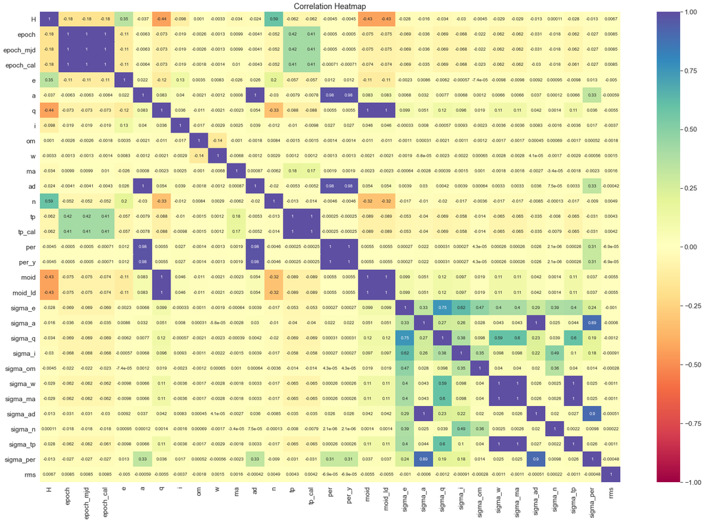

```python
# Check if any of columns correlated?
sns.set(rc={'figure.figsize':(30,20)}, font_scale=1.4)
corr_matrix=sns.heatmap(no_null_data.corr(), vmin=-1, vmax=1, cmap='Spectral', annot=True, annot_kws={"fontsize":10})
corr_matrix.set_title('Correlation Heatmap', fontdict={'fontsize':18})
```

Summary:

- **epoch** has strong relationship with **epoch_mjd** and **epoch_cal**, they both refer to epoch of osculation in different time unit.
- **tp** has strong relationship with **tp_cal**, they refer to time of perihelion passage in different time unit.
- **per** has strong relationship with **per_y**, they refer to sidereal orbital period in different time unit.
- **moid** has strong relationship with **moid_ld**, they refer to earth minimum orbit intersection distance in different length unit.
- **a** has strong relationship with **ad** and **per**.
- **q** has strong relatiosnhip with **moid**.
- **sigma_w** has strong relationship with **sigma_ma** and **sigma_tp**.

## Data Preprocessing

- Handle identifiers
- Encode categorical features and target
- Split train, validation, and test sets
- Normalize
- Handle class imbalance

```python
# Remove identifying columns
data=no_null_data.drop(['id', 'spkid', 'full_name', 'orbit_id', 'equinox'], axis=1).reset_index(drop=True)
```

After we cleaned data and removed identifying columns, we have three categorical features which are **neo**, **class**, and **pha**, and we have 31 numerical features.

```python
# Encode categorical features and target
one_hot_encoded_data=pd.get_dummies(data, columns=['neo', 'class'])
one_hot_encoded_data['pha'] = LabelEncoder().fit_transform(one_hot_encoded_data['pha'])
```

```python
# Split train, validation, and test sets
x=one_hot_encoded_data.drop('pha', axis=1)
y=one_hot_encoded_data['pha'].to_frame()
x_train, x_test, y_train, y_test=train_test_split(x, y, test_size=0.4, random_state=100, stratify=y)
x_val, x_test, y_val, y_test=train_test_split(x_test, y_test, test_size=0.5, random_state=100, stratify=y_test)
print("Shape of original dataset :", one_hot_encoded_data.shape)
print("Shape of x_train set", x_train.shape)
print("Shape of y_train set", y_train.shape)
print("Shape of x_validation set", x_val.shape)
print("Shape of y_validation set", y_val.shape)
print("Shape of x_test set", x_test.shape)
print("Shape of y_test set", y_test.shape)
```

```
Shape of original dataset : (932335, 46)
Shape of x_train set (559401, 45)
Shape of y_train set (559401, 1)
Shape of x_validation set (186467, 45)
Shape of y_validation set (186467, 1)
Shape of x_test set (186467, 45)
Shape of y_test set (186467, 1)
```

```python
# Normalizing the features
x_train=StandardScaler().fit_transform(x_train)
x_val=StandardScaler().fit_transform(x_val)
x_test=StandardScaler().fit_transform(x_test)
# Normalizing after splitting could prevent leaking information about the validation set into the train set
# StandardScaler() is useful in classification and Normalizer() is useful in regression
```

The target variable **pha** is highly imbalanced in the train set, 99.778% of asteroids are non-hazardous, and 0.221% of asteroids are hazardous.

```python
# Imbalance in target variable
y_train.value_counts()
```

```
pha
0      558161
1        1240
dtype: int64
```

```python
# Data Upsampling - SMOTE
x_train_us, y_train_us=SMOTE(sampling_strategy=0.5, random_state=100).fit_resample(x_train, y_train)
y_train_us.value_counts()
```

```
pha
0      558161
1      279080
dtype: int64
```

```python
# Data Undersampling - Random Undersampling
random_under_sampling=RandomUnderSampler(random_state=100)
x_train_us_rus, y_train_us_rus=random_under_sampling.fit_resample(x_train_us, y_train_us)
y_train_us_rus.value_counts()
```

```
pha
1      279080
0      279080
dtype: int64
```

We used seven machine learning models and one multilayer perceptron model based on our literature reviews. With binary classification, it is very intuitive to score the model in terms of scoring metrics such as precision, recall, and f1-score. We decided to use macro-averaging f1-score as metrics to evaluate the model's efficiency because all classes need to be treated equally to evaluate the classifier's overall performance concerning the most frequent class labels.

## Machine Learning Models

- Random Forest
- XGBoost
- Decision Tree
- Navie Bayes
- Logistic Regression
- Support Vector Machine (SVM)
- K-Nearest Neighbors (KNN)

### Random Forest (Literature Review Recommendation)

Random forest used to solve regression and classification problems consists of many decision trees. A random forest eradicates the limitations of the decision tree algorithm. It reduces the overfitting of the dataset and increases precision. It is used for the dataset with high dimensionality and does not need to make feature selection before modeling.

```python
start_time_rfc=datetime.now()

rfc=RandomForestClassifier(class_weight='balanced', random_state=100)
# Skip Hyperparameter Tuning part because parameter with dafult value get the highest accuracy of model
'''
# Hyperparameter Tuning
param_grid={'n_estimators': [100]}
            'max_depth': [80,90],
            'min_samples_split': [2,3],
            'min_samples_leaf': [8,10]}
gs_rfc=GridSearchCV(estimator=rfc, param_grid=param_grid, n_jobs=-1, cv=3)
gs_rfc.fit(x_train_us_rus, y_train_us_rus)

# Best estimator
best_gs_rfc=gs_rfc.best_estimator_
print("Best params",gs_rfc.best_params_)
'''
rfc.fit(x_train_us_rus, y_train_us_rus)

# Predict for validation set
y_val_pred=rfc.predict(x_val)

# Metrics
precision_rfc, recall_rfc, fscore_rfc, support_rfc = precision_recall_fscore_support(y_val, y_val_pred, average='macro')
print(classification_report(y_val, y_val_pred))

end_time_rfc=datetime.now()
time_rfc=str(end_time_rfc - start_time_rfc)
print('Duration:', time_rfc)
```

```
              precision    recall  f1-score   support

           0       1.00      1.00      1.00    186054
           1       0.98      0.43      0.60       413

    accuracy                           1.00    186467
   macro avg       0.99      0.71      0.80    186467
weighted avg       1.00      1.00      1.00    186467

Duration: 0:02:32.788212
```

### XGBoost

XGBoost stands for Extreme Gradient Boosting, which is an additive and sequential model where trees are grown in a sequential manner which converts weak learners into strong learners by adding weights to the weak learners and reducing the weights of the strong learners. So each tree learns and boosts from the previous tree grown. XGBoost is fast in training large datasets compared to other gradient boosting implementations. It has higher predicting power and performance and is commonly used and frequently makes its way to the top of the leaderboard of competitions in data science.

```python
start_time_xgbc=datetime.now()

xgbc=XGBClassifier(max_depth=10, learning_rate=0.1, n_estimators=1000, eval_metric='mlogloss', random_state=100)
# Skip Hyperparameter Tuning part because it takes one hour to complete
'''
# Hyperparameter Tuning
param_grid={'max_depth': [10],
            'learning_rate': [0.1],
            'n_estimators': [1000],
            'gamma': [0],
            'min_child_weight': [1],
            'max_delta_step': [6],
            'subsample': [1]
            'colsample_bytree': [1],
            'eval_metric':['mlogloss'],
            'nthread': [2],
            'colsample_bylevel': [1],
            'reg_alpha': [0, 1e-2, 1, 1e1],
            'reg_lambda': [0, 1e-2, 1, 1e1],
            'base_score': [0.5]}
gs_xgbc=GridSearchCV(estimator=xgbc, param_grid=param_grid, n_jobs=-1, cv=3)
gs_xgbc.fit(x_train_us_rus, y_train_us_rus)

# Best estimator
best_gs_xgbc=gs_xgbc.best_estimator_
print("Best params",gs_xgbc.best_params_)
'''
xgbc.fit(x_train_us_rus, y_train_us_rus)
# Predict for validation set
y_val_pred=xgbc.predict(x_val)

# Metrics
precision_xgbc, recall_xgbc, fscore_xgbc, support_xgbc = precision_recall_fscore_support(y_val, y_val_pred, average='macro')
print(classification_report(y_val, y_val_pred))

end_time_xgbc=datetime.now()
time_xgbc=str(end_time_xgbc-start_time_xgbc)
print('Duration:', time_xgbc)
```

```
              precision    recall  f1-score   support

           0       1.00      1.00      1.00    186054
           1       0.97      0.43      0.60       413

    accuracy                           1.00    186467
   macro avg       0.98      0.72      0.80    186467
weighted avg       1.00      1.00      1.00    186467

Duration: 0:04:47.720237
```

### Decision Tree

A decision tree is used to categorize or predict based on how a previous set of questions were answered. It is a robust model able to deal with class imbalance data. Also, it is simple to understand and interpret what features contribute to classification performance on safe and dangerous asteroids.

```python
start_time_dtc=datetime.now()

dtc=DecisionTreeClassifier(class_weight='balanced', random_state=100)
# Skip Hyperparameter Tuning part because parameter with dafult value get the highest accuracy of model
'''
# Hyperparameter Tuning
param_grid={'max_depth': [6],
            'criterion': ['gini'],
            'splitter': ['best'],
            'min_samples_split': [2],
            'min_samples_leaf': [1]}
gs_dtc=GridSearchCV(estimator=dtc, param_grid=param_grid, n_jobs=-1, cv=3)
gs_dtc.fit(x_train_us_rus, y_train_us_rus)

# Best estimator
best_gs_dtc=gs_dtc.best_estimator_
print("Best params",gs_dtc.best_params_)
'''
dtc.fit(x_train_us_rus, y_train_us_rus)
# Predict for validation set
y_val_pred=dtc.predict(x_val)

# Metrics
precision_dtc, recall_dtc, fscore_dtc, support_dtc = precision_recall_fscore_support(y_val, y_val_pred, average='macro')
print(classification_report(y_val, y_val_pred))

end_time_dtc=datetime.now()
time_dtc=str(end_time_dtc-start_time_dtc)
print('Duration:', time_dtc)
```

```
              precision    recall  f1-score   support

           0       1.00      1.00      1.00    186054
           1       0.94      0.43      0.59       413

    accuracy                           1.00    186467
   macro avg       0.97      0.72      0.80    186467
weighted avg       1.00      1.00      1.00    186467

Duration: 0:00:07.478281
```

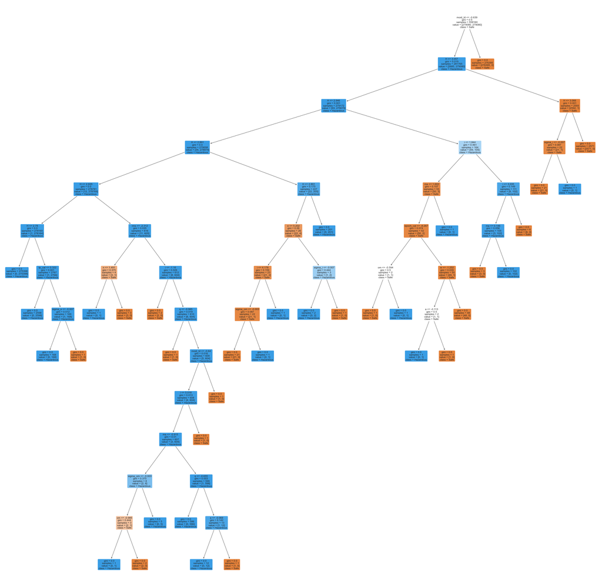

```python
# Plot Decision Tree
decision_tree=plt.figure(figsize=(50,50))
tree.plot_tree(dtc,
               feature_names=x.columns,
               rounded=True,
               filled=True,
               class_names=['Safe', 'Hazardous'],
               impurity=True)
decision_tree.savefig('Decistion_Tree.png')
```

### Navie Bayes

Naive Bayes is used to solving classification problems. For numerous data with many features, the best solution would be to use the Naive Bayes classifier, which is quite faster in comparison to other classification algorithms.

```python
start_time_gnb=datetime.now()

gnb=GaussianNB()
# Skip Hyperparameter Tuning part because parameter with dafult value get the highest accuracy of model
'''
# Hyperparameter Tuning
param_grid={'var_smoothing': np.logspace(0,-9,num=100)}
gs_gnb=GridSearchCV(estimator=gnb, param_grid=param_grid, n_jobs=-1, cv=3)
gs_gnb.fit(x_train_us_rus, y_train_us_rus)

# Best estimator
best_gs_gnb=gs_gnb.best_estimator_
print("Best params",gs_gnb.best_params_)
'''
gnb.fit(x_train_us_rus, y_train_us_rus)
# Predict for validation set
y_val_pred=gnb.predict(x_val)

# Metrics
precision_gnb, recall_gnb, fscore_gnb, support_gnb=precision_recall_fscore_support(y_val, y_val_pred, average='macro')
print (classification_report(y_val, y_val_pred))

end_time_gnb=datetime.now()
time_gnb=str(end_time_gnb-start_time_gnb)
print('Duration:', time_gnb)
```

```
              precision    recall  f1-score   support

           0       1.00      1.00      1.00    186054
           1       0.00      0.00      0.00       413

    accuracy                           1.00    186467
   macro avg       0.50      0.50      0.50    186467
weighted avg       1.00      1.00      1.00    186467

Duration: 0:00:00.889026
```

We found that Naive Bayes works poorly because it works well when all features are independent. In our dataset, the features are correlative. Thus Naive Bayes is broken and predicted all values 0 (not hazardous).

### Logistic Regression

Logistic regression is a classification algorithm used to find the probability of event success and event failure. It applies to our data because our dependent variable is binary (safe/dangerous). Also, it is very fast at classifying unknown records.

```python
start_time_lr=datetime.now()

lr=LogisticRegression(penalty='none', tol=10**-20, C=20, solver='newton-cg', max_iter=50, class_weight='balanced', random_state=100)
# Skip Hyperparameter Tuning part because parameter with dafult value get the highest accuracy of model
'''
# Hyperparameter Tuning
param_grid={
            'tol': [10**-20],
            'C':[20],
            'solver':['newton-cg'],
            'max_iter':[50]
            }
gs_lr=GridSearchCV(estimator=lr, param_grid=param_grid, n_jobs=-1, cv=3)
gs_lr.fit(x_train_us_rus, y_train_us_rus)

# Best estimator
best_gs_lr=gs_lr.best_estimator_
print("Best params",gs_lr.best_params_)
'''
lr.fit(x_train_us_rus, y_train_us_rus)
# Predict for validation set
y_val_pred=lr.predict(x_val)

# Metrics
precision_lr, recall_lr, fscore_lr, support_lr=precision_recall_fscore_support(y_val, y_val_pred, average='macro')
print(classification_report(y_val, y_val_pred))

end_time_lr=datetime.now()
time_lr=str(end_time_lr-start_time_lr)
print('Duration:', time_lr)
```

```
              precision    recall  f1-score   support

           0       1.00      1.00      1.00    186054
           1       0.73      0.85      0.79       413

    accuracy                           1.00    186467
   macro avg       0.87      0.93      0.89    186467
weighted avg       1.00      1.00      1.00    186467

Duration: 0:00:37.282234
```

### Support Vector Machine (SVM)

SVM is used for classification, regression, and outliers detection. It is effective in high-dimensional spaces.

```python
start_time_svc=datetime.now()

svc=SVC()
svc.fit(x_train_us_rus, y_train_us_rus)
# Predict for test set
y_test_pred=svc.predict(x_test)

# Metrics
precision_svc, recall_svc, fscore_svc, support_svc=precision_recall_fscore_support(y_test, y_test_pred, average='macro')
print(classification_report(y_test, y_test_pred))

end_time_svc=datetime.now()
time_svc=str(end_time_svc-start_time_svc)
print('Duration:', time_svc)
```

```
              precision    recall  f1-score   support

           0       1.00      0.99      1.00    186054
           1       0.25      1.00      0.40       413

    accuracy                           0.99    186467
   macro avg       0.62      1.00      0.70    186467
weighted avg       1.00      0.99      1.00    186467

Duration: 0:15:57.340256
```

### K-Nearest Neighbors (KNN)

The KNN algorithm classifies unclassified data points based on their proximity and similarity to other available data points. The underlying assumption this algorithm makes is that similar data points can be found near one another. It is versy easy to undersatand and implement.

```python
start_time_knc=datetime.now()

knc=KNeighborsClassifier(n_neighbors=1)
knc.fit(x_train_us_rus, y_train_us_rus)
# Predict for test set
y_test_pred=knc.predict(x_test)

# Metrics
precision_knc, recall_knc, fscore_knc, support_knc=precision_recall_fscore_support(y_test, y_test_pred, average='macro')
print(classification_report(y_test, y_test_pred))

end_time_knc=datetime.now()
time_knc=str(end_time_knc-start_time_knc)
print('Duration:', time_knc)
```

```
              precision    recall  f1-score   support

           0       1.00      1.00      1.00    186054
           1       0.31      0.69      0.43       413

    accuracy                           1.00    186467
   macro avg       0.65      0.84      0.71    186467
weighted avg       1.00      1.00      1.00    186467

Duration: 0:22:06.034381
```

## Neural Network

### Multilayer Perceptron Model (MLP Model)

```python
# Model Structure
dl_model=Sequential()
dl_model.add(Dense(10, activation='relu', input_shape=(45,)))
dl_model.add(BatchNormalization())
dl_model.add(Dense(200, activation='relu'))
dl_model.add(BatchNormalization())
dl_model.add(Dropout(0.05))
dl_model.add(Dense(200, activation='relu'))
dl_model.add(BatchNormalization())
dl_model.add(Dense(1, activation='sigmoid'))
```

```python
dl_model.summary()
```

```
Model: "sequential"
_________________________________________________________________
Layer (type)                 Output Shape              Param #
=================================================================
dense (Dense)                (None, 10)                460
_________________________________________________________________
batch_normalization (BatchNo (None, 10)                40
_________________________________________________________________
dense_1 (Dense)              (None, 200)               2200
_________________________________________________________________
batch_normalization_1 (Batch (None, 200)               800
_________________________________________________________________
dropout (Dropout)            (None, 200)               0
_________________________________________________________________
dense_2 (Dense)              (None, 200)               40200
_________________________________________________________________
batch_normalization_2 (Batch (None, 200)               800
_________________________________________________________________
dense_3 (Dense)              (None, 1)                 201
=================================================================
Total params: 44,701
Trainable params: 43,881
Non-trainable params: 820
_________________________________________________________________
```

```python
# Compile the model
dl_model.compile(optimizer=Adam(lr=0.001), loss='binary_crossentropy', metrics=['accuracy'])
```

```python
# Set callback
model_checkpoint_cb=ModelCheckpoint(filepath='MLP_model.h5',
                                    save_best_only=True,
                                    save_weights_only=True)
early_stopping_cb=EarlyStopping(monitor='val_loss',
                                mode='min',
                                verbose=1,
                                patience=15,
                                restore_best_weights=True)
reducelr_on_plateau_cb=ReduceLROnPlateau(factor=0.05, patience=3)
```

```python
start_time_dl=datetime.now()

dl_model_history=dl_model.fit(x_train_us_rus,y_train_us_rus,
                              epochs=100,
                              batch_size=110,
                              validation_data=(x_val,y_val),
                              callbacks=[model_checkpoint_cb, early_stopping_cb, reducelr_on_plateau_cb])
end_time_dl=datetime.now()
time_dl=str(end_time_dl-start_time_dl)
print('Duration:', time_dl)
```

```
Restoring model weights from the end of the best epoch.
Epoch 00025: early stopping
Duration: 0:04:29.396443
```

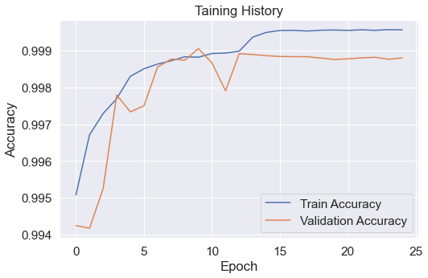

```python
# Evaluate traning history
plt.figure(figsize=(8,5))
plt.plot(dl_model_history.history['accuracy'])
plt.plot(dl_model_history.history['val_accuracy'])
plt.legend(['Train Accuracy', 'Validation Accuracy'])
plt.xlabel('Epoch')
plt.ylabel('Accuracy')
plt.title('Taining History')
plt.savefig('MLP_model_training_history.png')
```

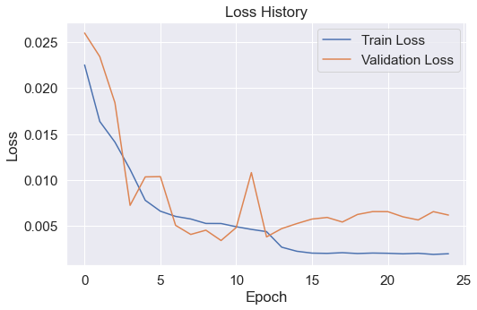

```python
# Evaluate loss history
plt.figure(figsize=(8,5))
plt.plot(dl_model_history.history['loss'])
plt.plot(dl_model_history.history['val_loss'])
plt.legend(['Train Loss', 'Validation Loss'])
plt.xlabel('Epoch')
plt.ylabel('Loss')
plt.title('Loss History')
plt.savefig('MLP_model_loss_history.png')
```

```python
# Predict for validation set
y_val_pred = dl_model.predict(x_val)
precision_dl, recall_dl, fscore_dl, support_dl=precision_recall_fscore_support(y_val, y_val_pred.round(), average='macro')
print(classification_report(y_val,y_val_pred.round()))
print('Duration:', time_dl)
```

```
              precision    recall  f1-score   support

           0       1.00      1.00      1.00    186054
           1       0.78      0.80      0.79       413

    accuracy                           1.00    186467
   macro avg       0.89      0.90      0.89    186467
weighted avg       1.00      1.00      1.00    186467

Duration: 0:04:29.396443
```

## Model Comparison

```python
# Model Comparsion
Model_Selection=pd.DataFrame({'Model':['Random Forest', 'XGBoost', 'Decision Tree', 'Navie Bayes', 'Logistic Regression', 'K-Nearest Neighbors', 'SVM', 'MLP Model'],
                              'Precision':[precision_rfc, precision_xgbc, precision_dtc, precision_gnb, precision_lr, precision_svc, precision_knc, precision_dl],
                              'Recall':[recall_rfc, recall_xgbc, recall_dtc, recall_gnb, recall_lr, recall_svc, recall_knc, recall_dl],
                              'F1 Score':[fscore_rfc, fscore_xgbc, fscore_dtc, fscore_gnb, fscore_lr, fscore_svc, fscore_knc, fscore_dl],
                              'Time':[time_rfc, time_xgbc, time_dtc, time_gnb, time_lr, time_svc, time_knc, time_dl]})
Model_Selection.index+=1
Model_Selection
```

[output not shown]

```python
# Load the best model and predict for validation set
dl_model.load_weights(filepath='Best_MLP_model.h5')
y_val_pred = dl_model.predict(x_val)
precision_dl, recall_dl, fscore_dl, support_dl=precision_recall_fscore_support(y_val, y_val_pred.round(), average='macro')
print(classification_report(y_val, y_val_pred.round()))
```

```
              precision    recall  f1-score   support

           0       1.00      1.00      1.00    186054
           1       0.78      0.98      0.87       413

    accuracy                           1.00    186467
   macro avg       0.89      0.99      0.94    186467
weighted avg       1.00      1.00      1.00    186467
```

```python
# Load the best model and predict for test set
dl_model.load_weights(filepath='Best_MLP_model.h5')
y_test_pred = dl_model.predict(x_test)
precision_dl, recall_dl, fscore_dl, support_dl=precision_recall_fscore_support(y_test, y_test_pred.round(), average='macro')
print(classification_report(y_test, y_test_pred.round()))
```

```
              precision    recall  f1-score   support

           0       1.00      1.00      1.00    186054
           1       0.84      0.92      0.88       413

    accuracy                           1.00    186467
   macro avg       0.92      0.96      0.94    186467
weighted avg       1.00      1.00      1.00    186467
```

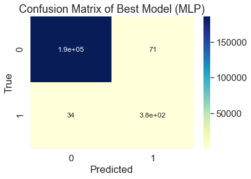

```python
# Confusion matrix
conf_matrix_best_model=confusion_matrix(y_test, y_test_pred.round())
sns.set(rc={'figure.figsize':(6,4)}, font_scale=1.4)
heatmap_best_model=sns.heatmap(conf_matrix_best_model, cmap='YlGnBu', annot=True, annot_kws={"size": 12})
heatmap_best_model.set_title('Confusion Matrix of Best Model (MLP)', fontdict={'fontsize':18})
heatmap_best_model.set_xlabel('Predicted')
heatmap_best_model.set_ylabel('True')
```

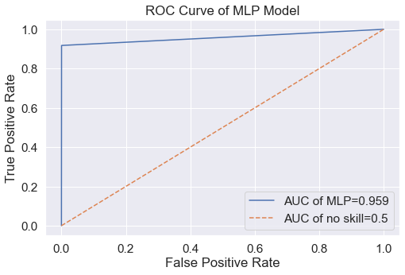

```python
# Generate a baseline (majority class)
y_test_bl = list(np.repeat(0, len(y_test)))

# Plot ROC curve
fpr_mlp, tpr_mlp, _ = metrics.roc_curve(y_test, y_test_pred.round())
fpr_bl, tpr_bl, _ = metrics.roc_curve(y_test, y_test_bl)
auc_mlp = round(metrics.roc_auc_score(y_test, y_test_pred.round()),3)
auc_bl = round(metrics.roc_auc_score(y_test, y_test_bl),3)
plt.figure(figsize=(8,5))
plt.plot(fpr_mlp, tpr_mlp, label="MLP Model")
plt.plot(fpr_bl, tpr_bl, linestyle="--", label="No Skill")
plt.ylabel('True Positive Rate')
plt.xlabel('False Positive Rate')
plt.title('ROC Curve of MLP Model')
plt.legend(["AUC of MLP="+str(auc_mlp), "AUC of no skill="+str(auc_bl)])
plt.savefig('MLP_model_ROC_Curve.png')
```

The more that the curve hugs the top left corner of the plot, the better the model does at classifying the data into categories. The AUC tells us how much of the plot is located under the curve. The closer AUC is to 1, the better the model. As we can see from the plot above, this MLP model does a excellent job of classifying the data iinto categories and AUC of this MLP model is 0.959.